**City College of San Francisco**

MATH 108 - Foundations of Data Science

# Lecture 07: Charts

Associated Textbook Sections: [7.0, 7.1](https://inferentialthinking.com/chapters/07/Visualization.html)

## Set Up the Notebook

```python
from datascience import *
import numpy as np
%matplotlib inline
import matplotlib.pyplot as plots
plots.style.use('fivethirtyeight')
```

## Numerical Data

### Visualizing the Distribution of One Numerical Variable

Histograms `hist` are a standard way to visualize the distribution of one numerical variable.

*Histograms will be focused on in the next lecture.*

#### A Histogram

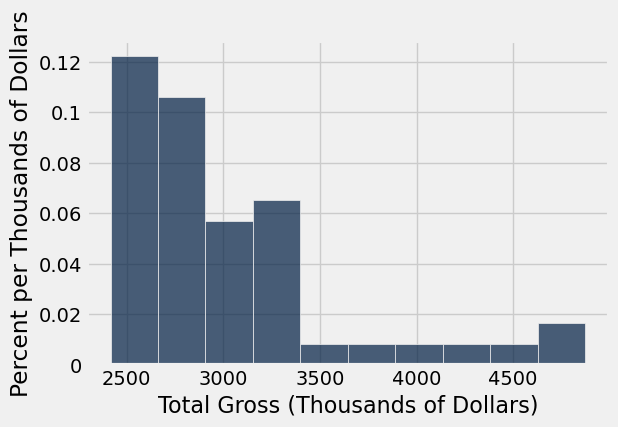

```python
actors = Table().read_table('data/actors.csv')
actors.hist('Total Gross', unit="Thousands of Dollars")
```

### Plotting Two Numerical Variables

Line graphs `plot` and Scatter plots `scatter` are standard ways to visualize the relationship of two numerical variables.

#### A Line Graph

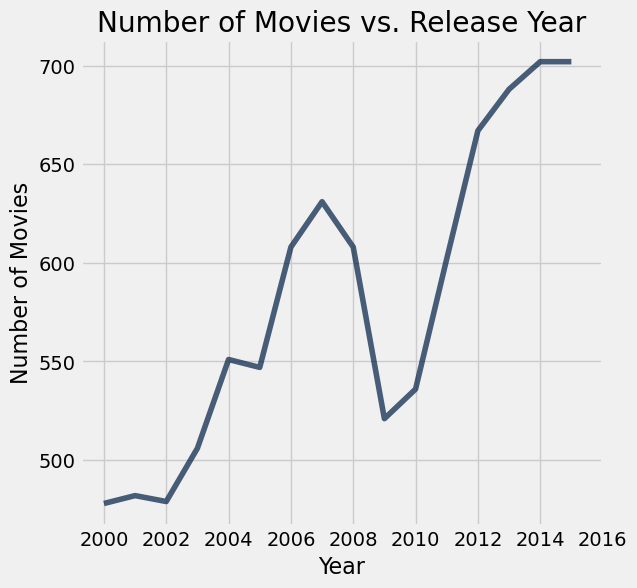

```python
movies = Table().read_table('data/movies_by_year.csv')
movies.where('Year', are.above(1999)).plot('Year', 'Number of Movies')
# Some extra graph formatting
plots.xticks(np.arange(2000, 2017, 2))
plots.title('Number of Movies vs. Release Year')
plots.show()
```

#### A Scatter Plot

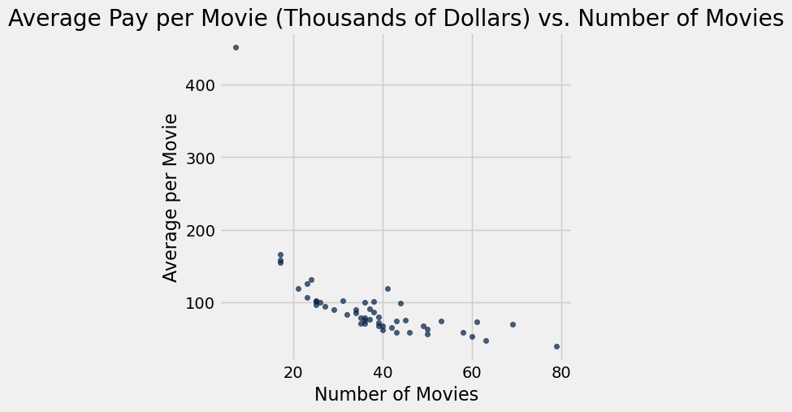

```python
actors = Table().read_table('data/actors.csv')
actors.scatter('Number of Movies', 'Average per Movie')
plots.title('Average Pay per Movie (Thousands of Dollars) vs. Number of Movies')
plots.show()
```

### When to use a line vs scatter plot?

- Use line plots for sequential data if:
  - ... your x-axis has an order
  - ... sequential differences in y values are meaningful
  - ... there's only one y-value for each x-value
- Usually: x-axis is time or distance
- Use scatter plots for non-sequential data --- When you’re looking for associations

### Demo: Census

Explore the US Census data from the [Annual Estimates of the Resident Population by Single Year of Age and Sex for the United States](https://www2.census.gov/programs-surveys/popest/technical-documentation/file-layouts/2010-2020/cc-est2020-agesex.pdf).

(Release date: June 2021, Updated January 2022 to include April 1, 2020 estimates)

```python
full = Table.read_table('https://www2.census.gov/programs-surveys/popest/datasets/2010-2020/national/asrh/nc-est2020-agesex-res.csv')
full
```

| SEX | AGE | CENSUS2010POP | ESTIMATESBASE2010 | POPESTIMATE2010 | POPESTIMATE2011 | POPESTIMATE2012 | POPESTIMATE2013 | POPESTIMATE2014 | POPESTIMATE2015 | POPESTIMATE2016 | POPESTIMATE2017 | POPESTIMATE2018 | POPESTIMATE2019 | POPESTIMATE2020 |
| --- | --- | --- | --- | --- | --- | --- | --- | --- | --- | --- | --- | --- | --- | --- |
| 0 | 0 | 3944153 | 3944160 | 3951495 | 3963264 | 3926731 | 3931411 | 3954973 | 3984144 | 3963268 | 3882437 | 3826908 | 3762227 | 3735010 |
| 0 | 1 | 3978070 | 3978090 | 3957904 | 3966768 | 3978210 | 3943348 | 3949559 | 3973828 | 4003586 | 3981864 | 3897917 | 3842257 | 3773884 |
| 0 | 2 | 4096929 | 4096939 | 4090799 | 3971498 | 3980139 | 3993047 | 3960015 | 3967672 | 3992657 | 4021261 | 3996742 | 3911822 | 3853025 |
| 0 | 3 | 4119040 | 4119051 | 4111869 | 4102429 | 3983007 | 3992839 | 4007852 | 3976277 | 3984985 | 4009060 | 4035053 | 4009037 | 3921526 |
| 0 | 4 | 4063170 | 4063186 | 4077511 | 4122252 | 4112849 | 3994539 | 4006407 | 4022785 | 3992241 | 4000394 | 4021907 | 4045996 | 4017847 |
| 0 | 5 | 4056858 | 4056872 | 4064653 | 4087770 | 4132349 | 4123745 | 4007123 | 4020489 | 4038022 | 4007233 | 4012789 | 4032231 | 4054336 |
| 0 | 6 | 4066381 | 4066412 | 4073031 | 4075153 | 4097860 | 4142923 | 4135738 | 4020428 | 4034969 | 4052428 | 4019106 | 4022432 | 4040169 |
| 0 | 7 | 4030579 | 4030594 | 4043100 | 4083399 | 4085255 | 4108453 | 4154947 | 4148711 | 4034355 | 4048430 | 4063647 | 4027876 | 4029753 |
| 0 | 8 | 4046486 | 4046497 | 4025624 | 4053313 | 4093553 | 4096033 | 4120476 | 4167765 | 4162142 | 4047130 | 4059209 | 4071894 | 4034785 |
| 0 | 9 | 4148353 | 4148369 | 4125413 | 4035854 | 4063662 | 4104437 | 4107986 | 4133426 | 4181069 | 4175085 | 4058207 | 4067320 | 4078668 |

... (296 rows omitted)

Select the `SEX`, `AGE`, `CENSUS2010POP`, and `POPESTIMATE2019` columns.

```python
partial = full.select('SEX', 'AGE', 'CENSUS2010POP', 'POPESTIMATE2019')
partial.show(4)
```

| SEX | AGE | CENSUS2010POP | POPESTIMATE2019 |
| --- | --- | --- | --- |
| 0 | 0 | 3944153 | 3762227 |
| 0 | 1 | 3978070 | 3842257 |
| 0 | 2 | 4096929 | 3911822 |
| 0 | 3 | 4119040 | 4009037 |

... (302 rows omitted)

Relabel the 2010 and 2019 columns.

```python
simple = partial.relabeled(2, '2010').relabeled(3, '2019')
simple.show(4)
```

| SEX | AGE | 2010 | 2019 |
| --- | --- | --- | --- |
| 0 | 0 | 3944153 | 3762227 |
| 0 | 1 | 3978070 | 3842257 |
| 0 | 2 | 4096929 | 3911822 |
| 0 | 3 | 4119040 | 4009037 |

... (302 rows omitted)

Sort by `AGE` in descending order.

```python
simple.sort('AGE', descending=True)
```

| SEX | AGE | 2010 | 2019 |
| --- | --- | --- | --- |
| 0 | 999 | 308745538 | 328329953 |
| 1 | 999 | 151781326 | 161692336 |
| 2 | 999 | 156964212 | 166637617 |
| 0 | 100 | 53364 | 100442 |
| 1 | 100 | 9162 | 23531 |
| 2 | 100 | 44202 | 76911 |
| 0 | 99 | 32266 | 56774 |
| 1 | 99 | 6073 | 14486 |
| 2 | 99 | 26193 | 42288 |
| 0 | 98 | 45900 | 85867 |

... (296 rows omitted)

Remove the 999 ages and focus just on the combined data where the `SEX` value is 0. Drop the `SEX` column since there is only one value there.

```python
no_999 = simple.where('AGE', are.below(999))
everyone = no_999.where('SEX', 0).drop('SEX')
everyone
```

| AGE | 2010 | 2019 |
| --- | --- | --- |
| 0 | 3944153 | 3762227 |
| 1 | 3978070 | 3842257 |
| 2 | 4096929 | 3911822 |
| 3 | 4119040 | 4009037 |
| 4 | 4063170 | 4045996 |
| 5 | 4056858 | 4032231 |
| 6 | 4066381 | 4022432 |
| 7 | 4030579 | 4027876 |
| 8 | 4046486 | 4071894 |
| 9 | 4148353 | 4067320 |

... (91 rows omitted)

Visualize the relationship between age and population size in 2010.

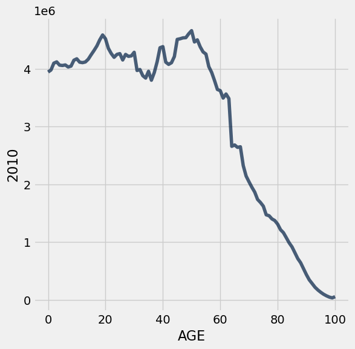

```python
everyone.plot('AGE', '2010')
```

Include lines for both 2010 and the estimated 2019 population sizes.

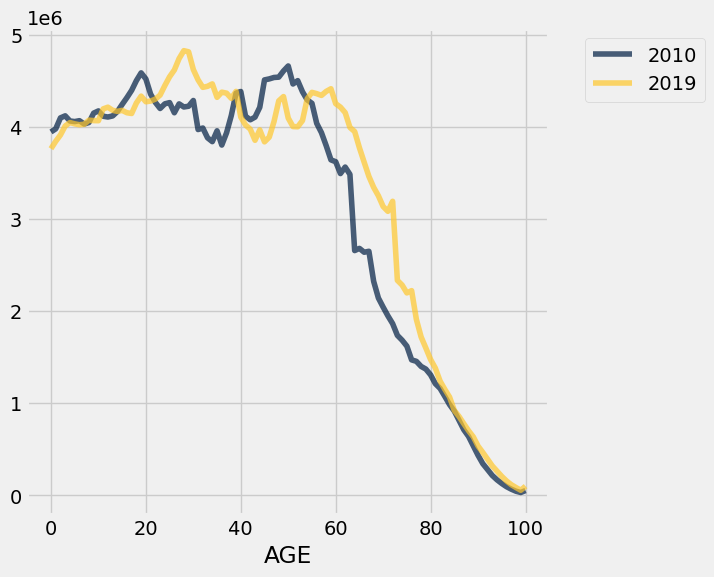

```python
everyone.plot('AGE') # datascience makes a line for every other numerical column
```

### Demo: Male and Female 2019 Estimates

Create a table with `Age`, `Males`, `Females` columns showing the population estimates in 2019 for males and females by age.

```python
males = no_999.where('SEX', 1).drop('SEX')
females = no_999.where('SEX', 2).drop('SEX')
pop_2019 = Table().with_columns(
    'Age', np.arange(0, 101),
    'Males', males.column('2019'),
    'Females' , females.column('2019')
)
pop_2019
```

| Age | Males | Females |
| --- | --- | --- |
| 0 | 1921001 | 1841226 |
| 1 | 1963261 | 1878996 |
| 2 | 2000102 | 1911720 |
| 3 | 2048651 | 1960386 |
| 4 | 2068251 | 1977745 |
| 5 | 2063176 | 1969055 |
| 6 | 2055583 | 1966849 |
| 7 | 2058425 | 1969451 |
| 8 | 2082403 | 1989491 |
| 9 | 2075719 | 1991601 |

... (91 rows omitted)

Visualize the distribution of of population size for both males and females.

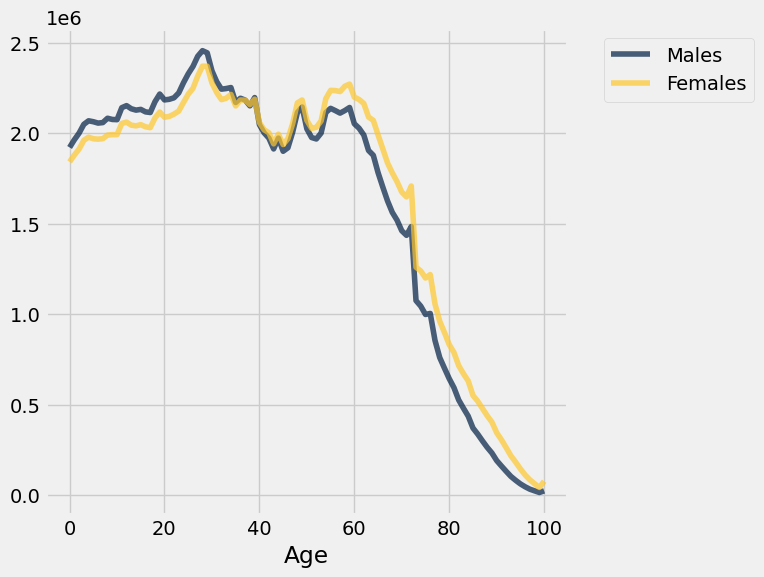

```python
pop_2019.plot('Age')
```

Calculate the percent female for each age

```python
total = pop_2019.column('Males') + pop_2019.column('Females')
pct_female = 100 * pop_2019.column('Females') / total
```

Round the values to 3 decimal places so that it's easier to read.

```python
pct_female = np.round(pct_female, 3)
```

Add female percent to our table

```python
pop_2019 = pop_2019.with_column('Percent female', pct_female)
pop_2019
```

| Age | Males | Females | Percent female |
| --- | --- | --- | --- |
| 0 | 1921001 | 1841226 | 48.94 |
| 1 | 1963261 | 1878996 | 48.903 |
| 2 | 2000102 | 1911720 | 48.87 |
| 3 | 2048651 | 1960386 | 48.899 |
| 4 | 2068251 | 1977745 | 48.882 |
| 5 | 2063176 | 1969055 | 48.833 |
| 6 | 2055583 | 1966849 | 48.897 |
| 7 | 2058425 | 1969451 | 48.896 |
| 8 | 2082403 | 1989491 | 48.859 |
| 9 | 2075719 | 1991601 | 48.966 |

... (91 rows omitted)

Visualize the relationship between age and the percent of the population that is female.

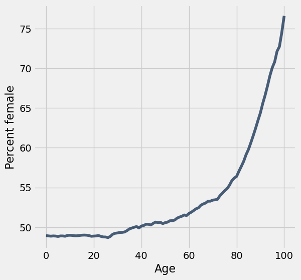

```python
pop_2019.plot('Age', 'Percent female')
```

Be careful of being visually mislead by the y-axis.

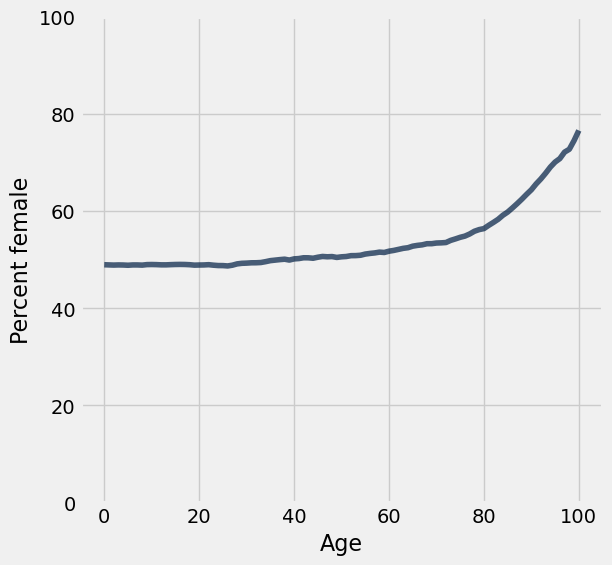

```python
pop_2019.plot('Age', 'Percent female')
plots.ylim(0, 100)
plots.show()
```

```python
Continue at 7:33
```

### Demo: Scatter Plots

```python
actors = Table.read_table('data/actors.csv')
actors
```

| Actor | Total Gross | Number of Movies | Average per Movie | #1 Movie | Gross |
| --- | --- | --- | --- | --- | --- |
| Harrison Ford | 4871.7 | 41 | 118.8 | Star Wars: The Force Awakens | 936.7 |
| Samuel L. Jackson | 4772.8 | 69 | 69.2 | The Avengers | 623.4 |
| Morgan Freeman | 4468.3 | 61 | 73.3 | The Dark Knight | 534.9 |
| Tom Hanks | 4340.8 | 44 | 98.7 | Toy Story 3 | 415 |
| Robert Downey, Jr. | 3947.3 | 53 | 74.5 | The Avengers | 623.4 |
| Eddie Murphy | 3810.4 | 38 | 100.3 | Shrek 2 | 441.2 |
| Tom Cruise | 3587.2 | 36 | 99.6 | War of the Worlds | 234.3 |
| Johnny Depp | 3368.6 | 45 | 74.9 | Dead Man's Chest | 423.3 |
| Michael Caine | 3351.5 | 58 | 57.8 | The Dark Knight | 534.9 |
| Scarlett Johansson | 3341.2 | 37 | 90.3 | The Avengers | 623.4 |

... (40 rows omitted)

Visualize the relationship between the number of movies and the total gross for each actor in the dataset.

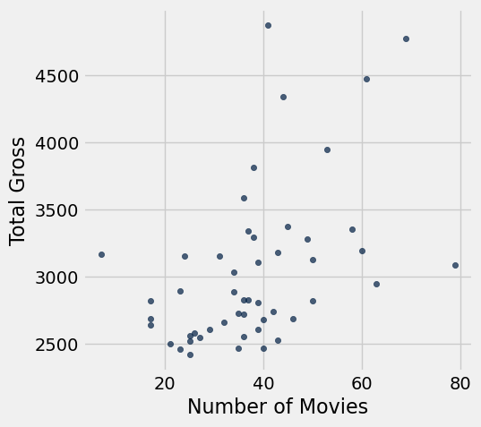

```python
actors.scatter('Number of Movies', 'Total Gross')
```

Visualize the relationship between the number of movies and the average pay per movie for each actor in the dataset.

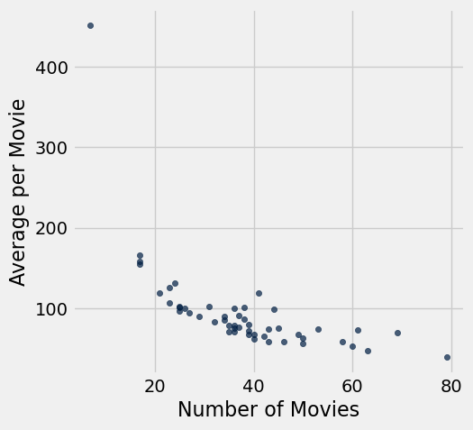

```python
actors.scatter('Number of Movies', 'Average per Movie')
```

Identify the outlier in the dataset.

```python
actors.where('Average per Movie', are.above(400))
```

| Actor | Total Gross | Number of Movies | Average per Movie | #1 Movie | Gross |
| --- | --- | --- | --- | --- | --- |
| Anthony Daniels | 3162.9 | 7 | 451.8 | Star Wars: The Force Awakens | 936.7 |

```python
actors.where('Number of Movies', are.above(70))
```

| Actor | Total Gross | Number of Movies | Average per Movie | #1 Movie | Gross |
| --- | --- | --- | --- | --- | --- |
| Robert DeNiro | 3081.3 | 79 | 39 | Meet the Fockers | 279.3 |

## Categorical Data

- (Horizontal) Bar charts `barh` are the standard way to visualize the distribution of a single categorical variable.
- Pie charts are generally discouraged because most people have a difficult time visually interpreting angles.

#### A Bar Chart

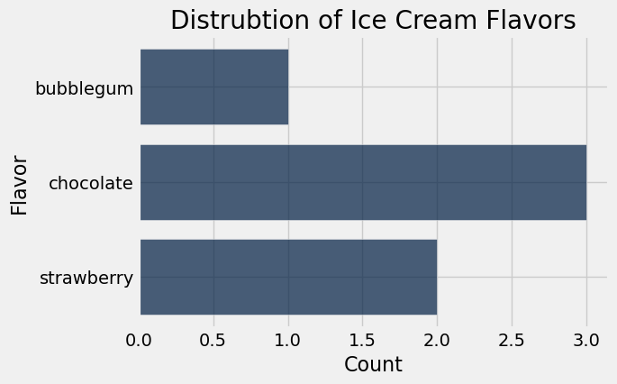

```python
cones = Table().read_table('data/cones.csv')
cones.group('Flavor').relabeled('count', 'Count').barh('Flavor')
plots.title('Distrubtion of Ice Cream Flavors')
plots.show()
```

### Demo: Bar Charts

Load the dataset showing the highest grossing movies as of 2017

```python
top_movies = Table.read_table('data/top_movies_2017.csv')
top_movies
```

| Title | Studio | Gross | Gross (Adjusted) | Year |
| --- | --- | --- | --- | --- |
| Gone with the Wind | MGM | 198676459 | 1796176700 | 1939 |
| Star Wars | Fox | 460998007 | 1583483200 | 1977 |
| The Sound of Music | Fox | 158671368 | 1266072700 | 1965 |
| E.T.: The Extra-Terrestrial | Universal | 435110554 | 1261085000 | 1982 |
| Titanic | Paramount | 658672302 | 1204368000 | 1997 |
| The Ten Commandments | Paramount | 65500000 | 1164590000 | 1956 |
| Jaws | Universal | 260000000 | 1138620700 | 1975 |
| Doctor Zhivago | MGM | 111721910 | 1103564200 | 1965 |
| The Exorcist | Warner Brothers | 232906145 | 983226600 | 1973 |
| Snow White and the Seven Dwarves | Disney | 184925486 | 969010000 | 1937 |

... (190 rows omitted)

Reduce the table to the top top 10 movies based on gross (adjusted) values.

```python
tbl = top_movies.sort('Gross (Adjusted)', descending=True).show(10) #doesn't work :(
tbl
```

| Title | Studio | Gross | Gross (Adjusted) | Year |
| --- | --- | --- | --- | --- |
| Gone with the Wind | MGM | 198676459 | 1796176700 | 1939 |
| Star Wars | Fox | 460998007 | 1583483200 | 1977 |
| The Sound of Music | Fox | 158671368 | 1266072700 | 1965 |
| E.T.: The Extra-Terrestrial | Universal | 435110554 | 1261085000 | 1982 |
| Titanic | Paramount | 658672302 | 1204368000 | 1997 |
| The Ten Commandments | Paramount | 65500000 | 1164590000 | 1956 |
| Jaws | Universal | 260000000 | 1138620700 | 1975 |
| Doctor Zhivago | MGM | 111721910 | 1103564200 | 1965 |
| The Exorcist | Warner Brothers | 232906145 | 983226600 | 1973 |
| Snow White and the Seven Dwarves | Disney | 184925486 | 969010000 | 1937 |

... (190 rows omitted)

```python
tbl.sort('Studio')
```

```
---------------------------------------------------------------------------
AttributeError                            Traceback (most recent call last)
Input In [53], in <cell line: 1>()
----> 1 tbl.sort('Studio')

AttributeError: 'NoneType' object has no attribute 'sort'
```

```python
top10 = top_movies.sort('Gross (Adjusted)', descending=True).take(np.arange(10))
top10
```

| Title | Studio | Gross | Gross (Adjusted) | Year |
| --- | --- | --- | --- | --- |
| Gone with the Wind | MGM | 198676459 | 1796176700 | 1939 |
| Star Wars | Fox | 460998007 | 1583483200 | 1977 |
| The Sound of Music | Fox | 158671368 | 1266072700 | 1965 |
| E.T.: The Extra-Terrestrial | Universal | 435110554 | 1261085000 | 1982 |
| Titanic | Paramount | 658672302 | 1204368000 | 1997 |
| The Ten Commandments | Paramount | 65500000 | 1164590000 | 1956 |
| Jaws | Universal | 260000000 | 1138620700 | 1975 |
| Doctor Zhivago | MGM | 111721910 | 1103564200 | 1965 |
| The Exorcist | Warner Brothers | 232906145 | 983226600 | 1973 |
| Snow White and the Seven Dwarves | Disney | 184925486 | 969010000 | 1937 |

Convert to the gross (adjusted) values to millions of dollars for readability.

```python
millions = np.round(top10.column('Gross (Adjusted)') / 1000000, 3)
top10 = top10.with_column('Millions', millions)
top10
```

| Title | Studio | Gross | Gross (Adjusted) | Year | Millions |
| --- | --- | --- | --- | --- | --- |
| Gone with the Wind | MGM | 198676459 | 1796176700 | 1939 | 1796.18 |
| Star Wars | Fox | 460998007 | 1583483200 | 1977 | 1583.48 |
| The Sound of Music | Fox | 158671368 | 1266072700 | 1965 | 1266.07 |
| E.T.: The Extra-Terrestrial | Universal | 435110554 | 1261085000 | 1982 | 1261.09 |
| Titanic | Paramount | 658672302 | 1204368000 | 1997 | 1204.37 |
| The Ten Commandments | Paramount | 65500000 | 1164590000 | 1956 | 1164.59 |
| Jaws | Universal | 260000000 | 1138620700 | 1975 | 1138.62 |
| Doctor Zhivago | MGM | 111721910 | 1103564200 | 1965 | 1103.56 |
| The Exorcist | Warner Brothers | 232906145 | 983226600 | 1973 | 983.227 |
| Snow White and the Seven Dwarves | Disney | 184925486 | 969010000 | 1937 | 969.01 |

Notice that a line plot doesn't really show a relationship between the year and the gross adjusted values.

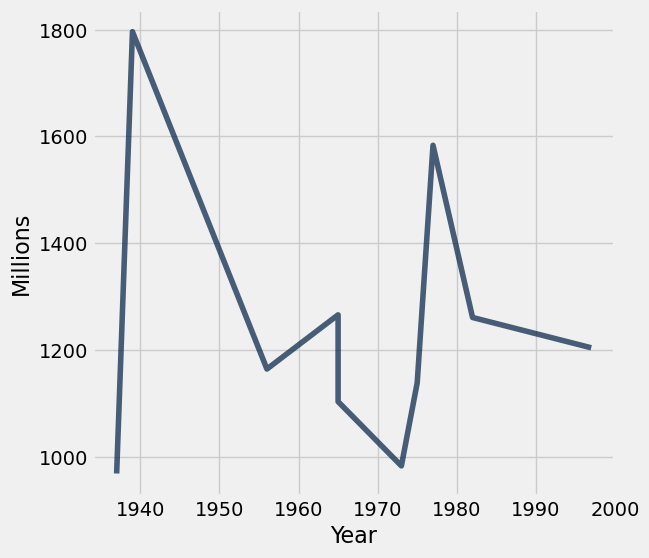

```python
top10.plot('Year', 'Millions')
```

Visualize the gross adjusted values for each of the top 10 grossing (adjusted) movies.

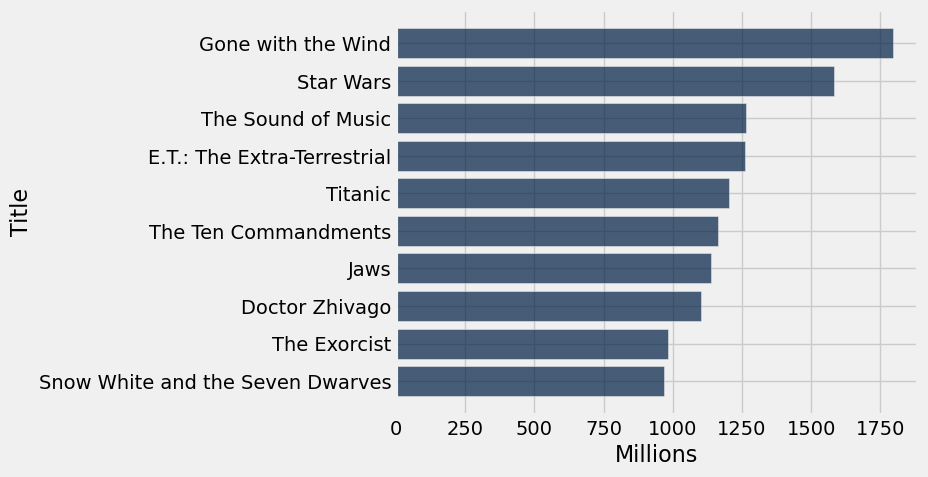

```python
top10.barh('Title', 'Millions')
```

Continue at 8:05